# GGPLOT2: uma introdução à gramática de gráficos

## Gráfico de barras

- Será que a instituição em que a pessoa estuda ou trabalha prevê se ela chamaria um pacote de Bono de biscoito ou bolacha?
- No caso de duas variáveis categóricas (dialeto e instituição), usa-se um gráfico de barras para indicar a quantidade ou porcentagem de uma variável em função de outra.
- Vamos começar com um gráfico simples, apenas indicando as instituições no eixo x e informando a geometria de barra.

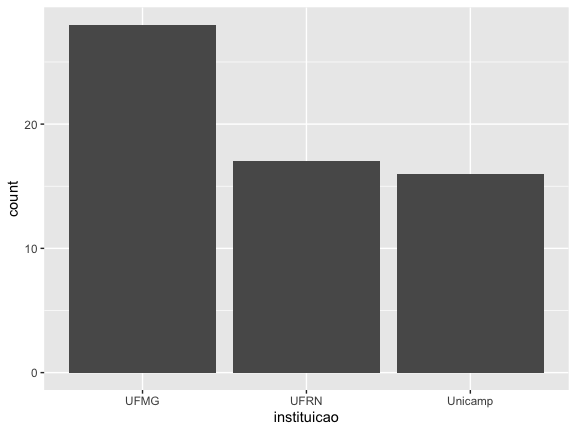

```r
# Gráfico de barra indicando frequência absoluta por instituição

ggplot(linguistas.edit, aes(x = instituicao))+
  geom_bar()
```

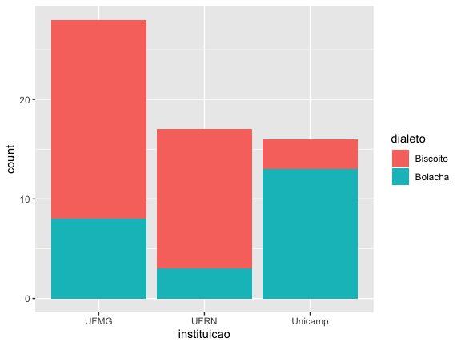

```r
# gráfico de instituição x dialeto: frequência absoluta

ggplot(linguistas.edit, aes(x = instituicao))+
  geom_bar(aes(fill = dialeto))
```

- Em vez de mostrar a frequência absoluta, podemos mostrar a frequência relativa do conjunto de dados.
- Para isso, indicamos na camada de geometria que o eixo y deverá mostrar o número de cada agrupamento de instituicao x dialeto (`...count..`) dividido pela soma total de dados `(sum(..count..))`.

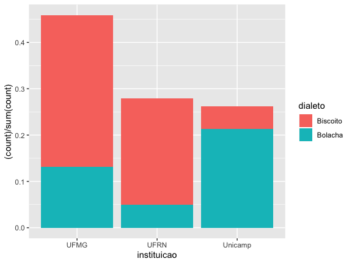

```r
# Gráfico com frequência relativa das ocorrência de instituição x dialeto

ggplot(linguistas.edit, aes(x = instituicao)) +
  geom_bar(aes(fill = dialeto, y = (..count..)/sum(..count..)))
```

- Isso nos retorna a frequência de ocorrência em um número de 0 a 1.
- Para transformar em porcentagem, acrecentamos uma função que indica mudança do tipo de escala usado no eixo y, e indicamos que a escala a ser usada deve ser porcentagem.

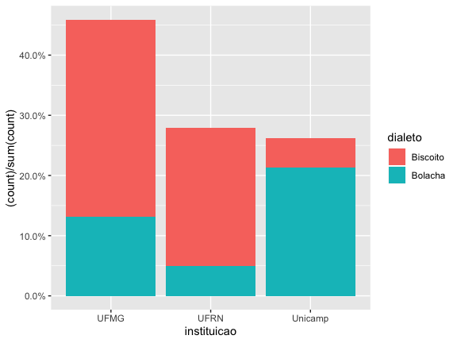

```r
# Gráfico com % das ocorrências de instituição x dialeto

ggplot(linguistas.edit, aes(x = instituicao)) +
  geom_bar(aes(fill = dialeto, y = (..count..)/sum(..count..)))+
  scale_y_continuous(labels=scales::percent)
```

- Ainda é possivel plotar as barras lado a lado (“dodged”) em vez de plotá-las uma acima da outra (“stacked”), que é o default do ggplot2.
- Para isso, é preciso apenas usar a função `position =` para informar que a posição da barra seja `"doge"`.

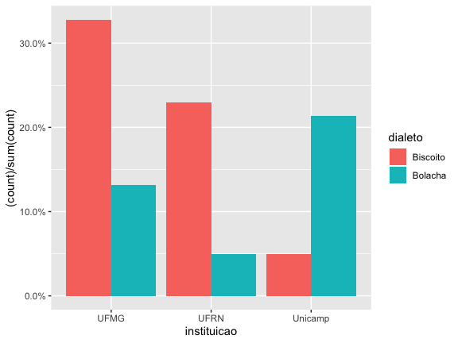

```r
# Gráfico com % das ocorrências de instituição x dialeto com barra dodged

ggplot(linguistas.edit, aes(x = instituicao)) +
  geom_bar(position = "dodge", aes(fill = dialeto, y = (..count..)/sum(..count..)))+
  scale_y_continuous(labels=scales::percent)
```

- Faz mais sentido comparar os dados se tomarmos cada instituição individualmente e calcular a porcentagem de bolacha/biscoito para ela.
- Isso é possível ao indicar que a função `position =` seja igual a “fill”.

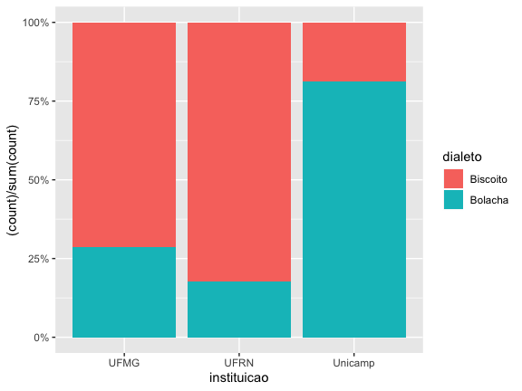

```r
# Gráfico para comparação entre % das taxas de dialeto em cada instituição

ggplot(linguistas.edit, aes(x = instituicao, fill = dialeto)) +
  geom_bar(aes(y = (..count..)/sum(..count..)), position = "fill")+
  scale_y_continuous(labels=scales::percent)
```

## Prática: barras

- Leia o código abaixo e tente adivinhar que tipo de gráfico ele construiria. Depois rode o código e veja se você acertou.

```r
ggplot(linguistas.edit, aes(x = instituicao, fill = deslocamento))+
  geom_bar(aes(y = (..count..)/sum(..count..)))+
  facet_wrap(~ status)
```

- Leia o código abaixo e tente descobrir porque ele não retorna o que descreve sua descrição. Arrume o código.

```r
# Gráfico de barra mostrando a proporção (em %) de pessoas que faz atividade física em cada uma das instituições; cada instituição tomada individualmente em 100%

ggplot(linguistas.edit, aes(x = instituicao)) +
  geom_bar(aes(y = (..count..)/sum(..count..)), position = "fill")+
  scale_y_continuous(labels=scales::percent)
```

- Crie um gráfico que mostre se gênero prevê a preferência por fazer ou não atividade física; como há mais mulheres que homens na amostra, normalize o gráfico para que cada barra some 100%, facilitando a comparação.

## Resumindo

- Três camadas são obrigatórias para a construção de um gráfico usando `ggplot2`:
  - dados
  - estética
  - geometria
- Além disso, há outras camadas que podem ser adicionadas para mostrar mais detalhes do gráfico.
- Uma camada bastante útil para comparar grupos é a *facet*.